# DLPI 2D - Workshop 3, Take-Home Assignment 3

m.faizal

Feb 2026

### Learning Objectives

This assignment builds on the skills developed in Workshops 1, 2 and 3. This may include:

- Skills from Workshops 1 and 2,
- K-means clustering,
- Hierarchical clustering.

### Requirements

- Update the author in the header of the RMD to include your NUSNET ID (the first part of your email address).
- Answer all questions within the R Markdown file, and knit it into HTML or PDF.
- Each question will specify what output is expected or required. Take note of any specific instructions for each question.
- Submit your `RMD` file **and** knitted `HTML` or `PDF` file via the Canvas assignment submission link.

Please reach out to your instructors as soon as possible if you are unsure about any of the submission requirements.

### Use of AI and Code Commenting

- You are encouraged to use generative AI to assist in the drafting or debugging of code. However, the final code must run and knit without errors.
- In accordance with NUS policies, you must declare the sections where you used AI, and the level of assistance that it provided.
- You are REQUIRED to add comments to your code by using the ‘*hash mark*’ symbol `#` at the start of your comments. These comments should concisely explain what your code is doing. This is an opportunity to explain other steps and checks that you undertook (such as manually reviewing the contents of a dataframe).

# Assignment Background

For this assignment, we will be comparing the outputs from k-means clustering and hierarchical clustering. The data for this assignment comes from the Tidy Tuesday project (https://github.com/rfordatascience/tidytuesday). This crowd-sourced project explores various interesting datasets.

We will be looking at data from Spotify in 2020. See the link for further details (https://github.com/rfordatascience/tidytuesday/tree/main/data/2020/2020-01-21). We want to explore relationships between a song’s genre and its key musical metrics. There are six genres in this dataset: EDM, Latin, Pop, R&B, Rap and Rock.

### Data Preparation

The following code chunk will load the required libraries and import the data. You will have one dataframe, `df`. Do not edit this chunk.

**Hint**: You must run the provided code first to import the data.

```r
library(pacman)
p_load(tidyverse, readxl, ggplot2, caret, cluster, factoextra, plotly)

df <- data.frame(read.csv(file = "../data/spotify_songs.csv")) %>%
  select(c(track_name, track_artist, track_popularity, playlist_genre,
           danceability, energy, tempo)) %>%
  filter(track_popularity > 75 & playlist_genre == "pop")
```

### Question 1 (3 marks)

**Problem**: We want to examine the relationships between the songs in this list. We suspect that there are relationships between the selected variables for each song.

We will start by exploring and preparing the data. Follow the commented prompts below.

**Output**: Store the manipulated data in a dataframe called `qn1`.

**Hint**: `qn1` should contain 693 rows, and `fivenum(qn1$track_popularity)` should give the following values (rounded): ‘| Min. | Q1 | Med. | Q3 | Max. |’———————————– ’| -1.08 |-0.88| -0.29 |0.49| 2.46 |

```r
# Use code to count the number of missing data points. Use the print() function to print the result into the console.
sum(is.na(df))
```

```
## [1] 0
```

```r
# Scale all numerical variables.
# Select relevant numeric features
df_numeric <- df %>% select(track_popularity, danceability, energy, tempo)

# Scale the data to normalise different value ranges.
df_scaled <- as.data.frame(scale(df_numeric))

# Detect and remove any outliers in the numerical data. Recall from DLPB how we used 1.5 x IQR to detect outliers. Hint, run ?quantile in the console.
# AI assistance: Suggested IQR-based outlier filtering structure
# manual review: verified five-number summary and number of rows after filtering
track_pop_quarts <- quantile(df_scaled$track_popularity, probs = seq(0, 1, 0.25))
track_pop_lower <- track_pop_quarts[2] - 1.5 * (track_pop_quarts[4] - track_pop_quarts[2])
track_pop_upper <- track_pop_quarts[4] + 1.5 * (track_pop_quarts[4] - track_pop_quarts[2])

danceability_quarts <- quantile(df_scaled$danceability, probs = seq(0, 1, 0.25))
danceability_lower <-  danceability_quarts[2] - 1.5 * (danceability_quarts[4] - danceability_quarts[2])
danceability_upper <-  danceability_quarts[4] + 1.5 * (danceability_quarts[4] - danceability_quarts[2])

energy_quarts <- quantile(df_scaled$energy, probs = seq(0, 1, 0.25))
energy_lower <-  energy_quarts[2] - 1.5 * (energy_quarts[4] - energy_quarts[2])
energy_upper <-  energy_quarts[4] + 1.5 * (energy_quarts[4] - energy_quarts[2])

tempo_quarts <- quantile(df_scaled$tempo, probs = seq(0, 1, 0.25))
tempo_lower <-  tempo_quarts[2] - 1.5 * (tempo_quarts[4] - tempo_quarts[2])
tempo_upper <-  tempo_quarts[4] + 1.5 * (tempo_quarts[4] - tempo_quarts[2])


# Now filter df based on the upper and lower bounds you calculated.
qn1 <- df_scaled %>%
  filter(track_popularity >= track_pop_lower & track_popularity <= track_pop_upper) %>%
  filter(danceability >= danceability_lower & danceability <= danceability_upper) %>%
  filter(energy >= energy_lower & energy <= energy_upper) %>%
  filter(tempo >= tempo_lower & tempo <= tempo_upper)

# Check your responses
NROW(qn1)
```

```
## [1] 693
```

```r
round(fivenum(qn1$track_popularity), 2)
```

```
## [1] -1.08 -0.88 -0.29  0.49  2.46
```

### Question 2 (4 marks)

**Problem**: We want to explore k-means clustering of songs based on `danceability`, `tempo` and `energy`.

In the code chunk below, conduct k-means clustering on the `qn1` dataframe using `danceability`, `tempo` and `energy`.

**Output**: Generate a scatterplot of the clustering and comment on the clustering findings and limitations.

```r
# Select the desired variables
qn1_desired <- qn1[, 2:4]
summary(qn1_desired)
```

```
##   danceability          energy             tempo
##  Min.   :-2.51835   Min.   :-2.84638   Min.   :-2.25204
##  1st Qu.:-0.62364   1st Qu.:-0.65375   1st Qu.:-0.75444
##  Median : 0.18141   Median : 0.15236   Median :-0.07105
##  Mean   : 0.04603   Mean   : 0.04551   Mean   :-0.11779
##  3rd Qu.: 0.71811   3rd Qu.: 0.80370   3rd Qu.: 0.36853
##  Max.   : 2.14930   Max.   : 1.84842   Max.   : 2.21295
```

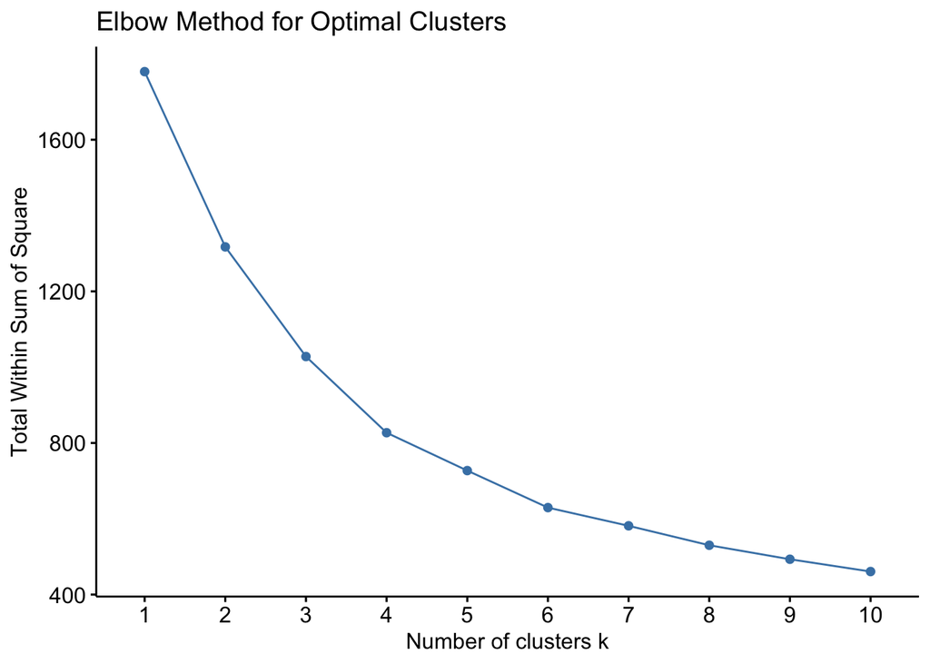

```r
# Determine the optimal number of clusters and comment on whether the number of clusters is good.
# optimal number of cluster is 3 as it decreases after 3.
fviz_nbclust(qn1_desired, kmeans, method = "wss") +
  ggtitle("Elbow Method for Optimal Clusters")
```

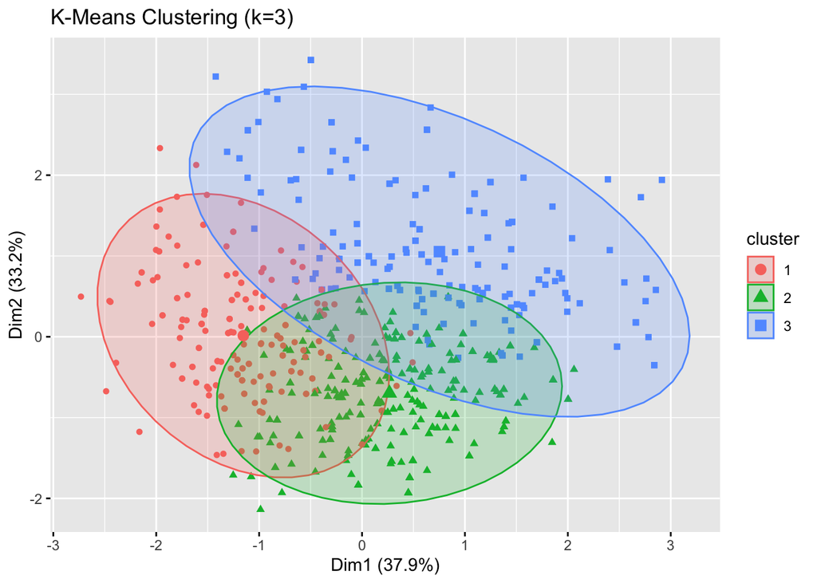

```r
# Use k = 3 clusters and conduct k-means clustering.
# For reproducibility
set.seed(123)

# k=3 clusters
k3 <- kmeans(qn1_desired, centers = 3, nstart = 25)

# Generate and interpret a scatterplot of these 3 clusters across the 3 selected variables.
# Visualise clusters using 2D scatter plot with color-coded clusters.
fviz_cluster(k3, data = qn1_desired, geom = "point", ellipse.type = "norm") +  ggtitle("K-Means Clustering (k=3)")
```

```r
# `danceability`, `tempo` and `energy, the cluster overlaps indicates that the songs variables correlated depending on the artist's intepretation.
```

### Question 3 (3 marks)

Let us repeat this clustering process with hierarchical clustering. Again we will reuse `danceability`, `tempo` and `energy` variables from the `qn1` dataframe.

**Output**: Generate a scatterplot and comment on the clustering findings and limitations.

```r
# Select the desired variables. Conduct hierarchical clustering using Euclidean distance and Ward Linkage, and cut the dendrogram to produce 3 clusters.
# Randomly sample 30 from the qn1_desired dataset
set.seed(10)
df1 <- qn1_desired[sample(nrow(qn1_desired), 30),]

#Calculate the distance matrix
df1_dist <- dist(df1, method="euclidean")

# Perform Hierarchical Clustering based on the Euclidean distance using Ward Linkage
df1_hc <- hclust(d=df1_dist, method="ward")
```

```
## The "ward" method has been renamed to "ward.D"; note new "ward.D2"
```

```r
# Obtain k=3 Hierarchical Cluster Assignments
df1$hcluster3 <- cutree(tree=df1_hc, k=3)

# Show the number of observations in each cluster group
table(df1$hcluster3)
```

```
##
##  1  2  3
## 14  9  7
```

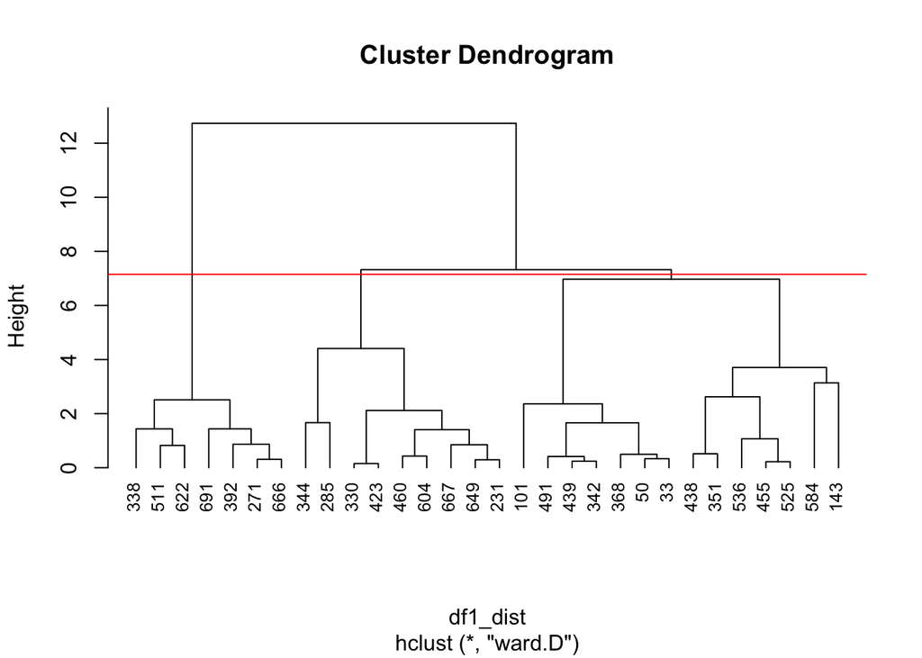

```
## integer(0)
```

```r
# Plot the dendrogram
plot(df1_hc, hang = -1, cex =0.8) +

# Draw a threshold line to cut dendogram to produce 3 clusters
abline(h = 7.15, lty = 1, col="red")
```

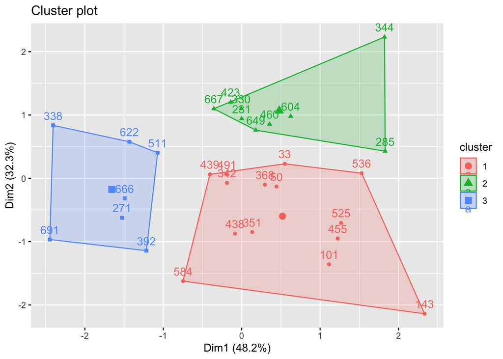

```r
# Generate and interpret a scatterplot of these 3 clusters across the 3 selected variables.
# Plot Hierarchical Clustering observations on a 2D plot
fviz_cluster(list(data=df1[,c("danceability", "tempo","energy")], cluster=df1$hcluster3))
```

```r
# Plot Hierarchical Clustering observations on a 3D plot
plot_ly(df1, x= ~danceability, y= ~tempo, z= ~energy, type="scatter3d", mode="markers", color =~hcluster3)
```

[interactive chart not shown]

```r
# Comment on any substantive differences in clustering between k-means and hierarchical clustering.
# k-means clusters overlap, reflecting correlations between the variables, whereas hierarchical clustering produces distinct, non-overlapping clusters, indicating clearer separation between groups.
```